# Peer graded Assignment, Prediction Assignment Writeup

ilias_369@hotmail.com

31/1/2021

## Project Backround

Using devices such as Jawbone Up, Nike FuelBand, and Fitbit it is now possible to collect a large amount of data about personal activity relatively inexpensively. These type of devices are part of the quantified self movement – a group of enthusiasts who take measurements about themselves regularly to improve their health, to find patterns in their behavior, or because they are tech geeks. One thing that people regularly do is quantify how much of a particular activity they do, but they rarely quantify how well they do it. In this project, your goal will be to use data from accelerometers on the belt, forearm, arm, and dumbell of 6 participants. They were asked to perform barbell lifts correctly and incorrectly in 5 different ways. More information is available from the website here: http://web.archive.org/web/20161224072740/http:/groupware.les.inf.puc-rio.br/har (see the section on the Weight Lifting Exercise Dataset).

## Purpose of this Project

The purpose of this project is to choose the appropriate machine learning algorithm to predict the manner in which the six participants performed the above exercises, using the “classe” variable in the training set. We will also use the prediction model to predict the 20 different test cases.

## Data Source

The data for this project came from the source: http://web.archive.org/web/20161224072740/http:/groupware.les.inf.puc-rio.br/har.

Reference: Velloso, E.; Bulling, A.; Gellersen, H.; Ugulino, W.; Fuks, H. “Qualitative Activity Recognition of Weight Lifting Exercises. Proceedings of 4th International Conference in Cooperation with SIGCHI (Augmented Human ’13)”. Stuttgart, Germany: ACM SIGCHI, 2013.

## Data Preparation

We begin with loading the data and the libraries we will use and setting the seed.

```r
library(caret)
library(gbm)
```

```r
library(rattle) #for the tree plot
set.seed(369)
```

```r
training <- read.csv("pml-training.csv")
testing <- read.csv("pml-testing.csv")
```

# Training set splitting & cleaning

We split the training set as follows:

```r
trainRule <- createDataPartition(y=training$classe, p=0.7, list=F)
training1 <- training[trainRule, ]
validation <- training[-trainRule, ]
```

In the data (both training and testing) there are many NA in specific columns (variables) and in fact these columns consist almost entirely of NA, so whole of them must be removed. Also we must remove all the near-zero variance predictors and 1-5 variables that can’t participate in prediction.

```r
#removing near-zero variance predictors
ZeroVar1 <- nearZeroVar(training)
training1Clear <- training1[, -ZeroVar1]
validationClear <- validation[, -ZeroVar1]

#removing predictors with many NA values
training1Clear <- training1Clear[, colSums(is.na(training1Clear)) == 0]
validationClear <- validationClear[, colSums(is.na(validationClear)) == 0]

#removing variables that can't participate in prediction
training1Clear <- training1Clear[, -(1:5)]
validationClear <- validationClear[, -(1:5)]
```

Testing set cleaning

```r
#removing near-zero variance predictors
ZeroVar2 <- nearZeroVar(testing)
testingClear <- testing[, -ZeroVar2]

#removing predictors with many NA values
testingClear <- testingClear[, colSums(is.na(testingClear)) == 0]

#removing variables that can't participate in prediction
testingClear <- testingClear[, -(1:5)]
```

## Building the candidate models

We will try 3 candidate models: 1) Recursive Partitioning and Regression Trees. 2) Generalized Boosted Model. 3) Random Forest Model.

# Recursive Partitioning and Regression Trees

First we fit the model and then we predict in validation set. As you can see below, this model has poor fit (Overall acurracy 0.5711) and is not suitable for predictions.

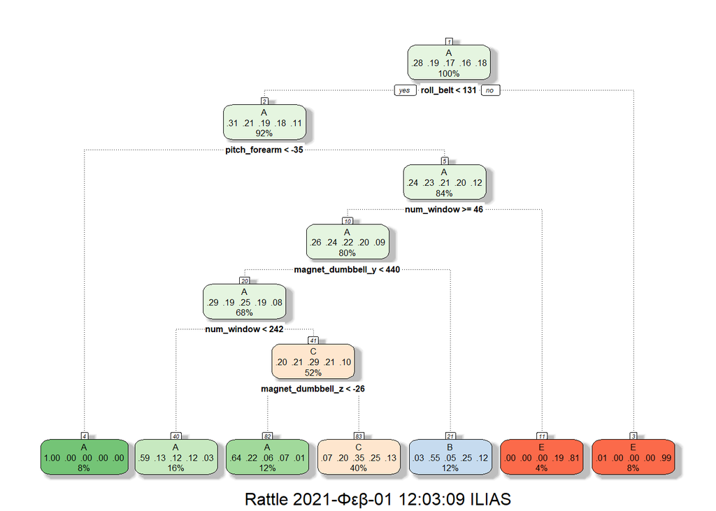

```r
r_part <- train(classe ~ ., data = training1Clear, method = "rpart")
fancyRpartPlot(r_part$finalModel)
```

```r
r_part_pred <- predict(r_part, newdata = validationClear)
r_part.Conf.Matrix <- confusionMatrix(r_part_pred,factor(validationClear$classe))
r_part.Conf.Matrix
```

```
## Confusion Matrix and Statistics
##
##           Reference
## Prediction    A    B    C    D    E
##          A 1470  275  156  167   43
##          B   27  399   32  164   86
##          C  175  465  838  582  299
##          D    0    0    0    0    0
##          E    2    0    0   51  654
##
## Overall Statistics
##
##                Accuracy : 0.5711
##                  95% CI : (0.5584, 0.5838)
##     No Information Rate : 0.2845
##     P-Value [Acc > NIR] : < 2.2e-16
##
##                   Kappa : 0.452
##
##  Mcnemar's Test P-Value : < 2.2e-16
##
## Statistics by Class:
##
##                      Class: A Class: B Class: C Class: D Class: E
## Sensitivity            0.8781   0.3503   0.8168   0.0000   0.6044
## Specificity            0.8478   0.9349   0.6870   1.0000   0.9890
## Pos Pred Value         0.6964   0.5636   0.3552      NaN   0.9250
## Neg Pred Value         0.9459   0.8571   0.9467   0.8362   0.9173
## Prevalence             0.2845   0.1935   0.1743   0.1638   0.1839
## Detection Rate         0.2498   0.0678   0.1424   0.0000   0.1111
## Detection Prevalence   0.3587   0.1203   0.4008   0.0000   0.1201
## Balanced Accuracy      0.8630   0.6426   0.7519   0.5000   0.7967
```

# Generalized Boosted Model

We will perform one time repeated 10-fold cross validation to Generalized Boosted and Random Forest Model.

```r
trainCtrl <- trainControl(method = "repeatedcv", number = 10, repeats = 1)
```

```r
GBM <- train(classe ~ ., data = training1Clear, method = "gbm",
                  trControl = trainCtrl, verbose = FALSE)
GBM$finalModel
```

```
## A gradient boosted model with multinomial loss function.
## 150 iterations were performed.
## There were 53 predictors of which 53 had non-zero influence.
```

The predictions on the validation set:

```r
GBMpred <- predict(GBM, newdata = validationClear)
GBM.Conf.Matrix <- confusionMatrix(GBMpred, factor(validationClear$classe))
GBM.Conf.Matrix
```

```
## Confusion Matrix and Statistics
##
##           Reference
## Prediction    A    B    C    D    E
##          A 1671    7    0    1    0
##          B    2 1115    7    7    5
##          C    0   17 1017   13    2
##          D    1    0    2  940   13
##          E    0    0    0    3 1062
##
## Overall Statistics
##
##                Accuracy : 0.9864
##                  95% CI : (0.9831, 0.9892)
##     No Information Rate : 0.2845
##     P-Value [Acc > NIR] : < 2.2e-16
##
##                   Kappa : 0.9828
##
##  Mcnemar's Test P-Value : NA
##
## Statistics by Class:
##
##                      Class: A Class: B Class: C Class: D Class: E
## Sensitivity            0.9982   0.9789   0.9912   0.9751   0.9815
## Specificity            0.9981   0.9956   0.9934   0.9967   0.9994
## Pos Pred Value         0.9952   0.9815   0.9695   0.9833   0.9972
## Neg Pred Value         0.9993   0.9949   0.9981   0.9951   0.9959
## Prevalence             0.2845   0.1935   0.1743   0.1638   0.1839
## Detection Rate         0.2839   0.1895   0.1728   0.1597   0.1805
## Detection Prevalence   0.2853   0.1930   0.1782   0.1624   0.1810
## Balanced Accuracy      0.9982   0.9873   0.9923   0.9859   0.9904
```

We can clearly see a very high overall accuracy of 0.9864, and also very high scores in all accuracy measures.

# Random Forest Model

We finally build a Random Forest Model (called RMD in R code):

```r
RMD <- train(classe ~ ., data = training1Clear, method = "rf",
                  trControl = trainCtrl, verbose = FALSE)
RMD$finalModel
```

```
##
## Call:
##  randomForest(x = x, y = y, mtry = param$mtry, verbose = FALSE)
##                Type of random forest: classification
##                      Number of trees: 500
## No. of variables tried at each split: 27
##
##         OOB estimate of  error rate: 0.21%
## Confusion matrix:
##      A    B    C    D    E  class.error
## A 3905    0    0    0    1 0.0002560164
## B    4 2652    2    0    0 0.0022573363
## C    0    5 2391    0    0 0.0020868114
## D    0    0    8 2243    1 0.0039964476
## E    0    1    0    7 2517 0.0031683168
```

The predictions on the validation set:

```r
RMDpred <- predict(RMD, newdata = validationClear)
RMD.Conf.Matrix <- confusionMatrix(RMDpred, factor(validationClear$classe))
RMD.Conf.Matrix
```

```
## Confusion Matrix and Statistics
##
##           Reference
## Prediction    A    B    C    D    E
##          A 1673    1    0    0    0
##          B    1 1137    0    0    0
##          C    0    1 1026    2    0
##          D    0    0    0  961    3
##          E    0    0    0    1 1079
##
## Overall Statistics
##
##                Accuracy : 0.9985
##                  95% CI : (0.9971, 0.9993)
##     No Information Rate : 0.2845
##     P-Value [Acc > NIR] : < 2.2e-16
##
##                   Kappa : 0.9981
##
##  Mcnemar's Test P-Value : NA
##
## Statistics by Class:
##
##                      Class: A Class: B Class: C Class: D Class: E
## Sensitivity            0.9994   0.9982   1.0000   0.9969   0.9972
## Specificity            0.9998   0.9998   0.9994   0.9994   0.9998
## Pos Pred Value         0.9994   0.9991   0.9971   0.9969   0.9991
## Neg Pred Value         0.9998   0.9996   1.0000   0.9994   0.9994
## Prevalence             0.2845   0.1935   0.1743   0.1638   0.1839
## Detection Rate         0.2843   0.1932   0.1743   0.1633   0.1833
## Detection Prevalence   0.2845   0.1934   0.1749   0.1638   0.1835
## Balanced Accuracy      0.9996   0.9990   0.9997   0.9981   0.9985
```

As it seems, the Random Forest Model perform almost perfect. The overall accuracy is 0.9985 and other accuracy measures are in the highest level.

## Applying the Random Forest Model to the 20 test cases

```r
testing.pred <- as.data.frame(predict(RMD, newdata = testingClear))
testing.pred
```

```
##    predict(RMD, newdata = testingClear)
## 1                                     B
## 2                                     A
## 3                                     B
## 4                                     A
## 5                                     A
## 6                                     E
## 7                                     D
## 8                                     B
## 9                                     A
## 10                                    A
## 11                                    B
## 12                                    C
## 13                                    B
## 14                                    A
## 15                                    E
## 16                                    E
## 17                                    A
## 18                                    B
## 19                                    B
## 20                                    B
```